# Clustering

2017-06-16

# 1 Clustering

Clustering is a big topic and hard to do it justice in a single module.

[Clustering](https://en.wikipedia.org/wiki/Cluster_analysis) is an unsupervised learning technique that attempts to group together similar observations. Clustering is commonly applied in Exploratory Data Analysis. Loosely speaking, a clustering algorithm aims to identify groups of observations that are close together (these are the “clusters”), but where there is a clear distinction between individual groups.

## 1.1 Distance Measures

Although the “normal” Euclidean distance might seem like the obvious choice when calculating the distance between points, it’s not always the *best* choice. Fortunately we have other options.

### 1.1.1 Standardising

Before calculating the distance between points it’s important to consider whether or not it’s meaningful to standardise the features. Why? Well, consider the following (somewhat contrived) data, where height is measured in mm and mass is given in 1000 kg.

```r
people
```

```
        height       mass
Jimmie    1922 0.10774111
Lewis     1758 0.07666979
Hollis    1794 0.08046581
Jody      1812 0.09647637
Timothy   1700 0.08272671
```

[figure not shown]

The Euclidean distance between these points is completely dominated by the `height` column. Objectively we see that Jody and Hollis are quite different, yet according to the distance measure they are the most similar pair of points.

```r
dist(people, diag = TRUE)
```

```
           Jimmie     Lewis    Hollis      Jody   Timothy
Jimmie    0.00000
Lewis   164.00000   0.00000
Hollis  128.00000  36.00000   0.00000
Jody    110.00000  54.00000  18.00001   0.00000
Timothy 222.00000  58.00000  94.00000 112.00000   0.00000
```

This issue arises because the distance is being calculated from two features with

1. different units; and
2. different scales.

In order to make a more sensible distance calculation we need to rectify both of these issues. This can be done by simply standardising each feature.

```r
(people <- scale(people))
```

```
             height       mass
Jimmie   1.52499335  1.4610026
Lewis   -0.47900432 -0.9376718
Hollis  -0.03910239 -0.6446228
Jody     0.18084857  0.5913760
Timothy -1.18773521 -0.4700840
attr(,"scaled:center")
      height         mass
1.797200e+03 8.881596e-02
attr(,"scaled:scale")
     height        mass
81.83642221  0.01295354
```

The standardised variables are dimensionless and also have the same mean and variance. Their influence on the distance metric is thus equitable. Let’s take another look.

```r
dist(people, diag = TRUE)
```

```
           Jimmie     Lewis    Hollis      Jody   Timothy
Jimmie  0.0000000
Lewis   3.1256432 0.0000000
Hollis  2.6229857 0.5285749 0.0000000
Jody    1.6009296 1.6653507 1.2554168 0.0000000
Timothy 3.3298636 0.8490805 1.1618180 1.7319697 0.0000000
```

With standardised features Lewis and Hollis are the closest points, which ties up with what we observe from the plot above.

Of course, it’s possible that you might want to have a non-uniform contribution to the distance measure, in which case by all means do not standardise your data. However, most often this is a step that you will want to take.

### 1.1.2 Euclidean Distance

We’ already seen how the Euclidean distance is calculated. Perhaps this is a good opportunity to have a look at some other features of `dist()`. Firstly, since the diagonal elements are all zero, by default these are not printed.

```r
dist(people)
```

```
           Jimmie     Lewis    Hollis      Jody
Lewis   3.1256432
Hollis  2.6229857 0.5285749
Jody    1.6009296 1.6653507 1.2554168
Timothy 3.3298636 0.8490805 1.1618180 1.7319697
```

You can also choose to include the upper (symmetric) portion of the distance matrix.

```r
dist(people, upper = TRUE)
```

```
           Jimmie     Lewis    Hollis      Jody   Timothy
Jimmie            3.1256432 2.6229857 1.6009296 3.3298636
Lewis   3.1256432           0.5285749 1.6653507 0.8490805
Hollis  2.6229857 0.5285749           1.2554168 1.1618180
Jody    1.6009296 1.6653507 1.2554168           1.7319697
Timothy 3.3298636 0.8490805 1.1618180 1.7319697
```

### 1.1.3 Manhattan Distance

The [Manhattan Distance](https://en.wikipedia.org/wiki/Taxicab_geometry) is also known as the “city block” distance. It’s calculated as the sum of the displacement along each of the coordinate axes (rather than along the diagonal). In two dimensions, this is the sum of the length of the two perpendicular sides of the triangle rather than the hypotenuse.

```r
dist(people, method = "manhattan")
```

```
           Jimmie     Lewis    Hollis      Jody
Lewis   4.4026720
Hollis  3.6697211 0.7329509
Jody    2.2137714 2.1889007 1.4559498
Timothy 4.6438152 1.1763186 1.3231716 2.4300438
```

This might be used, for example, to calculate the shortest distance that a vehicle must travel between two points within a city, since the vehicle is confined to moving along the grid of city streets.

### 1.1.4 Minkowski Distance

The [Minkowski Distance](https://en.wikipedia.org/wiki/Minkowski_distance) is a weird animal. It’s a generalisation of both the Euclidean and Manhattan distances. The measure is parameterised by $p$, where $p = 1$ gives the Manhattan distance and $p = 2$ is the Euclidean distance.

```r
dist(people, method = "minkowski", p = 1)
```

```
           Jimmie     Lewis    Hollis      Jody
Lewis   4.4026720
Hollis  3.6697211 0.7329509
Jody    2.2137714 2.1889007 1.4559498
Timothy 4.6438152 1.1763186 1.3231716 2.4300438
```

```r
dist(people, method = "minkowski", p = 2)
```

```
           Jimmie     Lewis    Hollis      Jody
Lewis   3.1256432
Hollis  2.6229857 0.5285749
Jody    1.6009296 1.6653507 1.2554168
Timothy 3.3298636 0.8490805 1.1618180 1.7319697
```

I understand that the Minkowski distance can be useful with larger values of $p$, but to be honest I’ve not yet come across a situation where I’ve needed to use it.

### 1.1.5 Other Metrics

There are a few other distance measures available via `dist()`.

# 2 $k$-Means Clustering

In [$k$-Means Clustering](https://en.wikipedia.org/wiki/K-means_clustering) one must specify the number of clusters in advance. The algorithm then proceeds as follows:

1. Randomly assign observations to each cluster.
2. Find the centroid of each cluster.
3. Find the distance from each point to the centroid of every cluster.
4. Assign points to the closest cluster.
5. If clusters have changed, return to 2. Otherwise exit.

These steps are followed until a predefined number of iterations is reached or qthere is no further variation within the clusters.

Note that $k$-Means Clustering does not require the calculation of a distance matrix.

An alternative to $k$-Means Clustering is $k$ Medoids Clustering, which is implemented in `pam()` from the `cluster` package.

## 2.1 Example: `iris`

The `iris` data are a great candidate for $k$-means clustering since we know the expected number of clusters.

[figure not shown]

Based on the distribution of the data we should expect that setosa should easily resolve into a separate cluster but that versicolor and virginica might well be more tricky.

To keep ourselves honest, we’ll make sure that we have an unsupervised problem. For these data the clusters are actually worse after standardising the data, so we won’t do that!

```r
species <- iris$Species
iris <- select(iris, -Species)
```

```r
set.seed(7)
(iris.kmeans <- kmeans(iris, 3, nstart = 20))
```

```
K-means clustering with 3 clusters of sizes 38, 62, 50

Cluster means:
  Sepal.Length Sepal.Width Petal.Length Petal.Width
1     6.850000    3.073684     5.742105    2.071053
2     5.901613    2.748387     4.393548    1.433871
3     5.006000    3.428000     1.462000    0.246000

Clustering vector:
  [1] 3 3 3 3 3 3 3 3 3 3 3 3 3 3 3 3 3 3 3 3 3 3 3 3 3 3 3 3 3 3 3 3 3 3 3 3 3 3 3 3 3 3 3 3 3 3 3
 [48] 3 3 3 2 2 1 2 2 2 2 2 2 2 2 2 2 2 2 2 2 2 2 2 2 2 2 2 2 2 2 1 2 2 2 2 2 2 2 2 2 2 2 2 2 2 2 2
 [95] 2 2 2 2 2 2 1 2 1 1 1 1 2 1 1 1 1 1 1 2 2 1 1 1 1 2 1 2 1 2 1 1 2 2 1 1 1 1 1 2 1 1 1 1 2 1 1
[142] 1 2 1 1 1 2 1 1 2

Within cluster sum of squares by cluster:
[1] 23.87947 39.82097 15.15100
 (between_SS / total_SS =  88.4 %)

Available components:

[1] "cluster"      "centers"      "totss"        "withinss"     "tot.withinss" "betweenss"
[7] "size"         "iter"         "ifault"
```

Since the initial assignment of observations to clusters is randomised, the final result might be variable. Therefore, to ensure reproducible results it’s important to seed your RNG. Also it’s possible to execute the algorithm multiple times (using the `nstart` parameter), which will mitigate against unfortunate initial cluster assignment which might cause the algorithm to converge to a local optimum.

We can check the cluster assignments against the known labels.

```r
table(species, iris.kmeans$cluster)
```

```
species       1  2  3
  setosa      0  0 50
  versicolor  2 48  0
  virginica  36 14  0
```

This confirms our suspicions: setosa was cleanly separated into a single cluster. However, the incidences of versicolor and virginica have been split between two clusters. There is a tendency for virginica to be found in cluster 1 and versicolor to be assigned to cluster 2, but this is clearly not the outcome that we were looking for. Perhaps the situation could be improved with some feature engineering?

Suppose that we didn’t know the right number of clusters in advance. How could we generate a decent guess? We could look at what fraction of the variance in the data is explained by a given clustering.

```r
iris.kmeans$betweenss / iris.kmeans$totss
```

```
[1] 0.8842753
```

The *between sum of squares* (`betweenss`) and *total sum of squares* (`totss`) are calculated with respect to the global centroid of the entire data set. The latter is the sum of square differences of each point with respect to the global centroid. The former is the sum of square differences for each point replaced by its cluster centroid.

Obviously, as the number of clusters increases, the positions of the points within the clusters will become closer to the cluster centroids, and this ratio will approach 100%. Another way of looking at this is that as the number of clusters approaches the number of points in the data, the number of points per cluster declines until each cluster consists of only a single point.

Let’s do this systematically by changing the number of clusters.

```r
ratios = sapply(1:10, function(k) {
  with(kmeans(iris, k, nstart = 20), betweenss / totss)
})
```

[figure not shown]

Finally, let’s take a quick swing at $k$ Medoids Clustering.

```r
library(cluster)
iris.pam <- pam(iris, 3)
```

[figure not shown]

# 3 Hierarchical Clustering

[Hierarchical Clustering](https://en.wikipedia.org/wiki/Hierarchical_clustering) does not produce a single set of clusters, rather it constructs a hierarchy of clusters. It’s then possible to cut across the hierarchy to select a clustering structure with a specific level of complexity. There are two classes of hierarchical clustering algorithms:

- **Agglomerative:** a *bottom-up* approach where initially every observation is a cluster and these clusters are progressively merged until all observations are in a single cluster;
- **Divisive:** a *top-down* approach where all observations are initially in a single cluster, which is then recursively split until every observation is a cluster.

Both of these approaches can become computationally expensive with large data sets.

We’re going to use data from the `cluster` package. We’ll focus on a subset of `votes.repub` (percent of votes given to the Republican candidate in presidential elections) where there are no missing data.

```r
votes.repub <- select(votes.repub, X1960:X1976)
```

## 3.1 Example: Agglomerative Clustering

Let’s cluster the voting data using an agglomerative clustering algorithm.

```r
votes.dist <- dist(votes.repub)
(votes.hclust <- hclust(votes.dist))
```

```
Call:
hclust(d = votes.dist)

Cluster method   : complete
Distance         : euclidean
Number of objects: 50
```

This is what the results look like:

[figure not shown]

The structure of the tree does not require explanation. However, perhaps the interpretation of the `Height` axis does. This can loosely be interpreted as the distance between clusters. So, for example, the clusters which are merged towards the bottom of the dendrogram are close together, while those that are merged near to the top of the dendrogram are far apart.

We can extract concrete clusters from this tree (or “dendrogram”) using `cutree()`. Suppose that we can to divide the states into 3 clusters.

```r
cutree(votes.hclust, k = 3)
```

```
       Alabama         Alaska        Arizona       Arkansas     California       Colorado
             1              2              2              3              2              2
   Connecticut       Delaware        Florida        Georgia         Hawaii          Idaho
             2              2              3              3              3              2
      Illinois        Indiana           Iowa         Kansas       Kentucky      Louisiana
             2              2              2              2              2              1
         Maine       Maryland  Massachusetts       Michigan      Minnesota    Mississippi
             2              2              3              2              2              1
      Missouri        Montana       Nebraska         Nevada  New Hampshire     New Jersey
             2              2              2              2              2              2
    New Mexico       New York North Carolina   North Dakota           Ohio       Oklahoma
             2              2              3              2              2              2
        Oregon   Pennsylvania   Rhode Island South Carolina   South Dakota      Tennessee
             2              2              3              3              2              3
         Texas           Utah        Vermont       Virginia     Washington  West Virginia
             2              2              2              3              2              2
     Wisconsin        Wyoming
             2              2
```

We could achieve a similar effect by cutting the tree at a specified height by using the `h` parameter to `cutree()`.

Another route to agglomerative clustering is via `agnes()`.

## 3.2 Linkage

You may have noted above that the cluster method used was “complete”. What does this mean? When clusters are being combined we need to measure the distance between clusters so that we can identify which ones are closest together. There are various ways to do this, the most important of which are:

- **Complete Linkage:** consider all pairs of points from two clusters and the distance between those clusters is taken as the distance between the pair of points which are *furthest apart*;
- **Single Linkage:** similar to complete linkage, but the distance between clusters is determined by the points which are *closest together*.

[figure not shown]

Using complete linkage, clusters 1 and 2 would be considered closest. However, with single linkage clusters 2 and 3 would be closest.

Complete linkage is the default in `hclust()`.

The choice of linkage function can, in some cases, have a big effect on the shape of clusters identified in hierarchical clustering.

Let’s cluster the voting data using single linkage.

```r
(votes.hclust <- hclust(votes.dist, method = "single"))
```

```
Call:
hclust(d = votes.dist, method = "single")

Cluster method   : single
Distance         : euclidean
Number of objects: 50
```

This is what the results look like:

[figure not shown]

## 3.3 Example: Divisive Clustering

```r
votes.diana <- diana(votes.dist)
```

It’s worth printing `votes.diana` because it captures a lot of information. It’s a little too lengthy to include here though.

We see that the resulting dendrogram is not significantly different to what we obtained with agglomerative clustering.

[figure not shown]

# 4 Density-Based Clustering

In density-based clustering, clusters are identified as regions with a high density of points separated from other such regions by areas with depleted point density.

Advantages of density-based clustering: - the number of clusters need not be specified in advance; - clusters can have arbitrarily complicated shapes; and - not sensitive to outliers.

However, this technique will fail if there are no clearly defined density depletions between clusters. It can also be tricky to select appropriate values for the parameters which are used to identify the “edge” of high density regions.

There are a few different techniques for density-based clustering, but we will focus on [Density-Based Spatial Clustering of Applications with Noise (DBSCAN)](https://en.wikipedia.org/wiki/DBSCAN).

We’ll illustrate density-based clustering with a scaled version of `iris`.

```r
iris.scaled <- scale(iris[, 1:4])
```

The core function for density-based clustering is `dbscan()` from the `dbscan` package.

```r
library(dbscan)
```

There are two key parameters which influence the performance of `dbscan()`: - `eps`: the radius of a region around a point which is used to identify other points which might be part of the same cluster; and - `minPts`: the minimum number of points required to form a dense region.

In the figure below the parameter `minPts` is set to 4. All of the red points are grouped into a single cluster because for each of them there are at least four points within a region of radius `eps`. The two yellow points are on the fringe of this cluster since they lie within a radius `eps` of one of the cluster points. The blue point is outside the cluster.

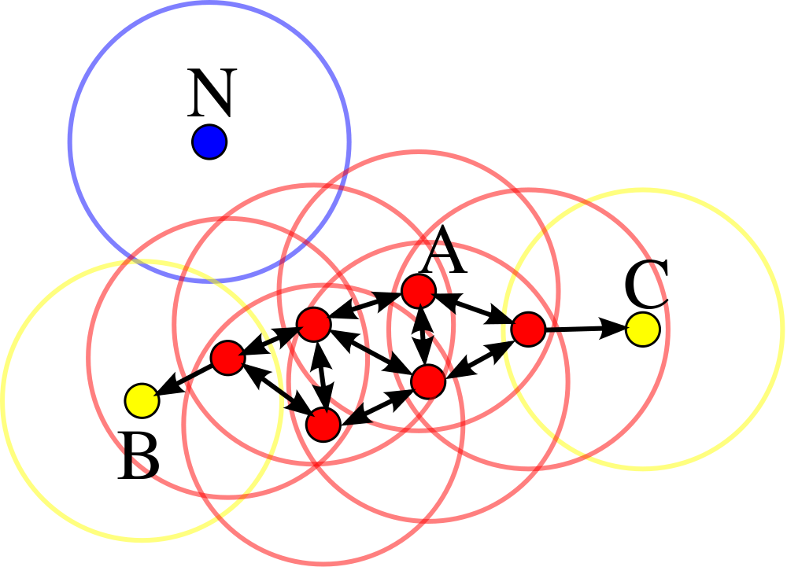

Illustration of DBSCAN from Wikipedia.

A value around 4 or 5 is normally appropriate for `minPts`.

However we need to estimate a suitable value for `eps` from the data. We can do this using `kNNdistplot()` which reflects the distribution of the typical distances between points. The “knee” in this curve is generally a good starting point for `eps`.

```r
kNNdistplot(iris.scaled)
#
eps_estimate = 0.75
#
abline(h = eps_estimate, col = "red", lty = "dashed")
```

[figure not shown]

The plot above indicates that the majority of points are less than 0.75 distant from their four nearest neighbours. This seems like a reasonable value to use for `eps`.

```r
(iris.dbscan <- dbscan(iris.scaled, eps_estimate))
```

```
DBSCAN clustering for 150 objects.
Parameters: eps = 0.75, minPts = 5
The clustering contains 2 cluster(s) and 5 noise points.

 0  1  2
 5 49 96

Available fields: cluster, eps, minPts
```

We can visualise the results.

```r
library(factoextra)
fviz_cluster(iris.dbscan, iris.scaled, geom = "point")
```

[figure not shown]

The points above are projected from the four dimensional space of the data onto the first two Principal Components. The black points were not assigned to either cluster and are considered to be “outliers”.

We can compare the clusters to the known species.

```r
table(species, iris.dbscan$cluster)
```

```
species       0  1  2
  setosa      1 49  0
  versicolor  0  0 50
  virginica   4  0 46
```

It’s apparent that DBSCAN readily separates the *setosa* records but is unable to discriminate between *versicolor* and *virginica*.

Varying `eps` would have a significant effect on the outcome of this analysis. A larger `eps` would ultimately result in the two clusters merging into a single cluster. Using smaller `eps` will result in the two clusters being broken down into smaller clusters, which will progressively get further away from the known division in the data.

# 5 Exercises

1. Use $k$-Means Clustering to group the observations in the `mtcars` data. Is it important to standardise these data first? Vary the number of clusters and choose an appropriate value for $k$. Interpret the clusters.
2. Use the `animals` data from the `cluster` package to perform hierarchical clustering. Try different distance measures and select the one that makes the most sense. Check `?dist` to ensure that you understand how missing values are treated.
3. Perform hierarchical clustering on the `mtcars` data. Plot the dendrogram. Does the structure make sense?
4. Perform hierarchical clustering on the `USArrests` data. Try all possible linkage methods and see what effect they have on the results.

# Resources

Galili, Tal. 2015. “dendextend: an R package for visualizing, adjusting and comparing trees of hierarchical clustering.” *Bioinformatics* 31 (22): 3718–20. doi:10.1093/bioinformatics/btv428.

Tan, Pang-Ning, Michael Steinbach, and Vipin Kumar. 2005. *Introduction to Data Mining*. Pearson. http://www-users.cs.umn.edu/{~}kumar/dmbook/index.php.